# Monterey County Office of Education Dashboard DA Summary

## Report Purpose

This report is created to assist Monterey County Office of Education in reflecting on the student groups whose indicators led to Differentiated Assistance.

The graphic below shows the color for each student group for each indicator from the [California Dashboard 2023](https://www.caschooldashboard.org/reports/27102720000000/2023)

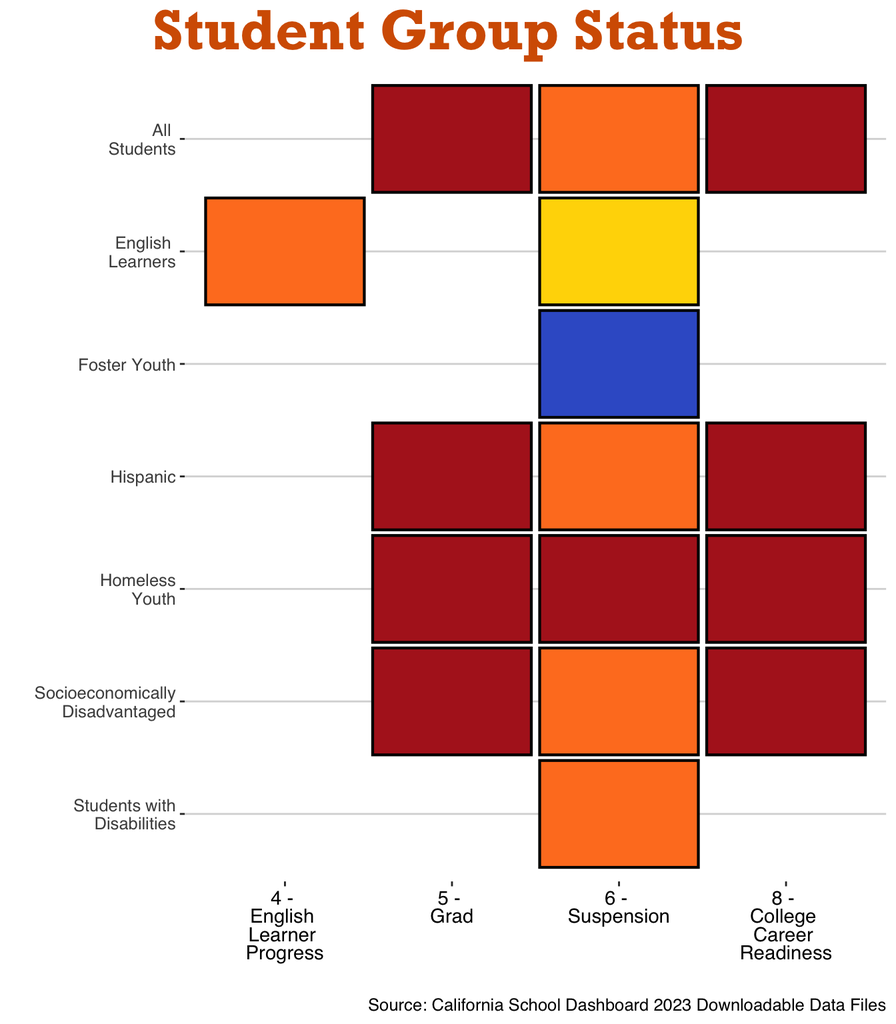

## Qualifying Groups

Differentiated Assistance is determined by the California Dashboard. Colors reflect the latest available status from 2023.

The table below displays which student groups qualified Monterey County Office of Education to be eligible for [Differentiated Assistance](https://www.cde.ca.gov/ta/ac/cm/leaproposedcrit.asp) by meeting the criteria for two or more LCFF priority areas according to California Education Code Section 52071(c). [California’s System of Support](https://www.cde.ca.gov/sp/sw/t1/csss.asp). The table shows for each student group which Priority Areas and associated indicators met qualification criteria.

| Student Group | Qualifying Priority Areas |
| --- | --- |
| Hispanic | Met Criteria in Priority Areas 5 (Chronic Absenteeism and/or Graduation) and 8 (College/Career) |
| Homeless Youth | Met Criteria in Priority Areas 5 (Chronic Absenteeism and/or Graduation), 6 (Suspensions), and 8 (College/Career) |
| Socioeconomically Disadvantaged | Met Criteria in Priority Areas 5 (Chronic Absenteeism and/or Graduation) and 8 (College/Career) |

## Status Details for all Indicators

These graphs represent all of the indicators from the Dashboard and show how each of the student groups performed. The light grey arrows represent change from the prior year. Arrows pointing to the right increased and to the left decreased, and the longer the tail length the greater the change.

**Click here to display graphs**

[figure not shown]

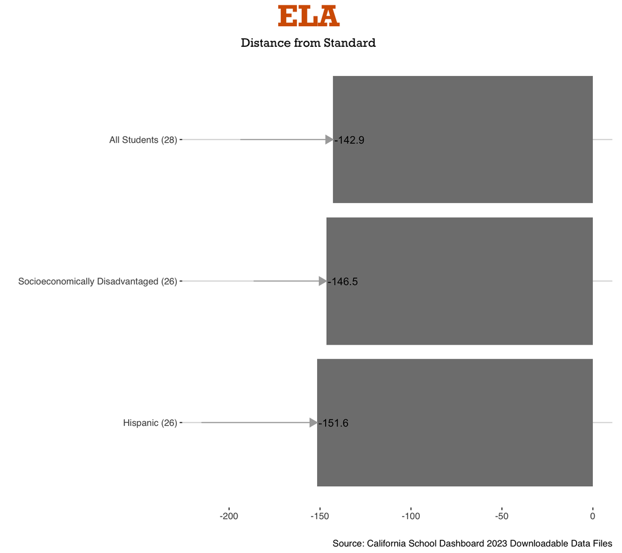

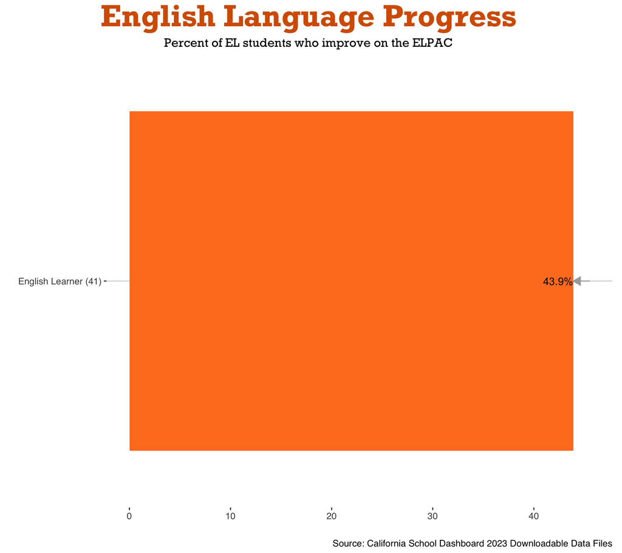

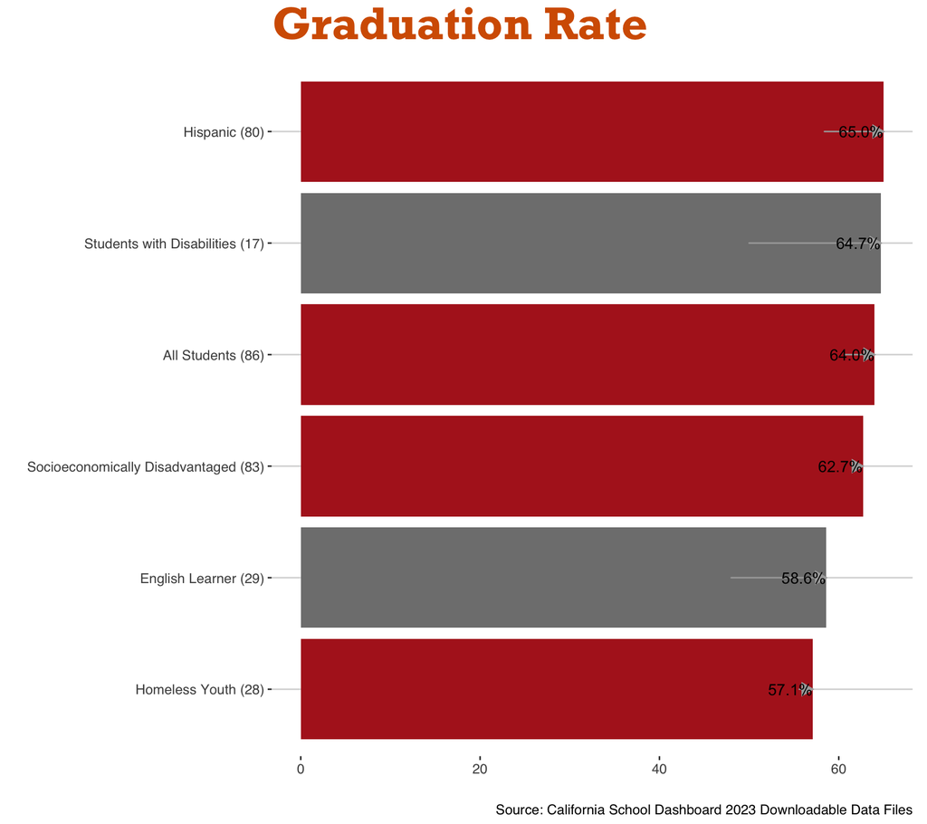

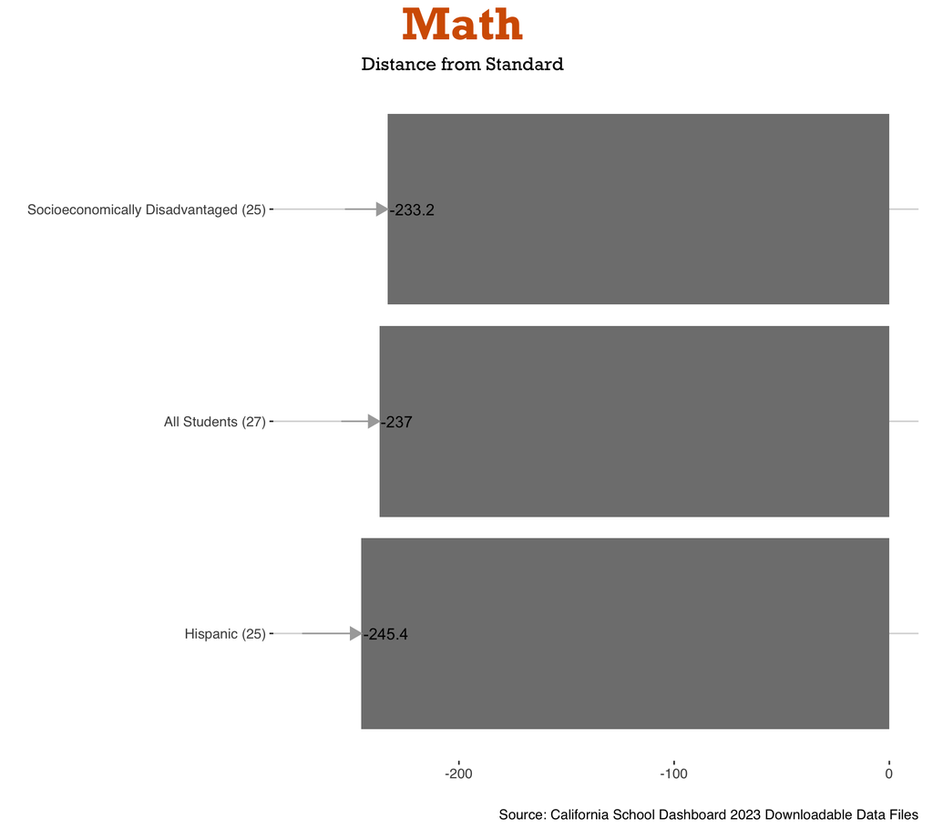

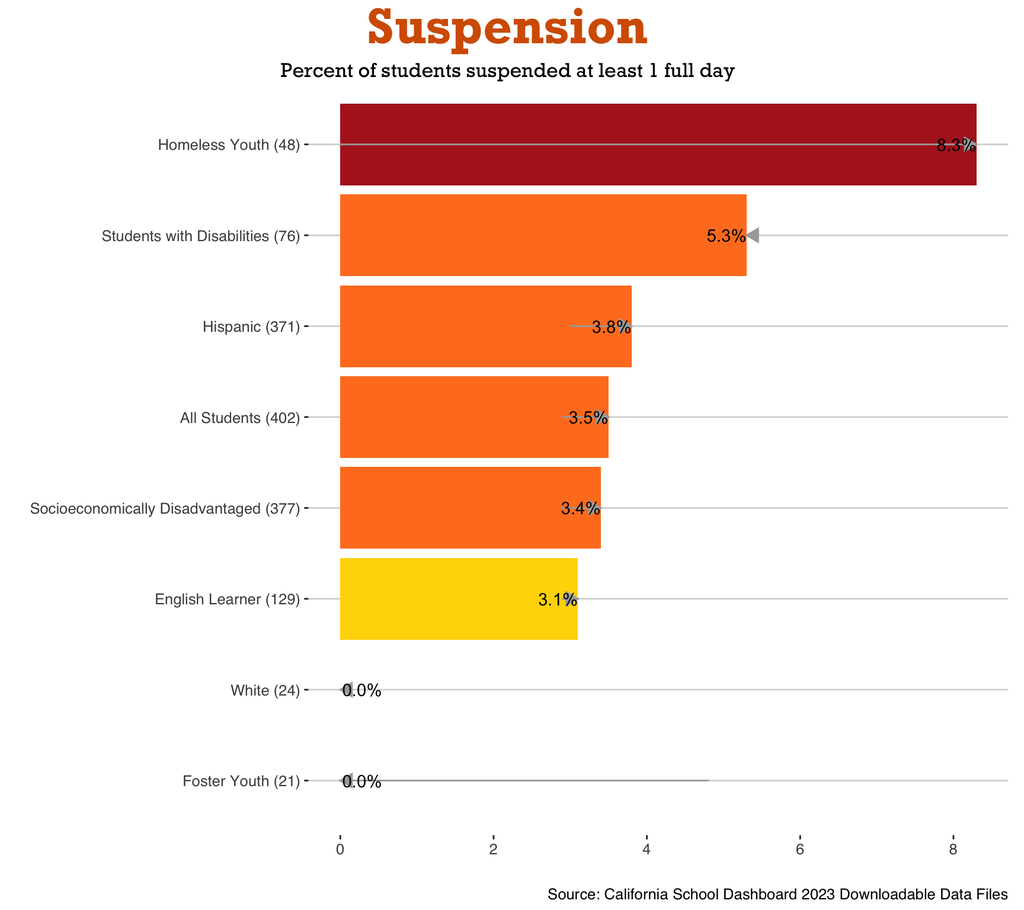

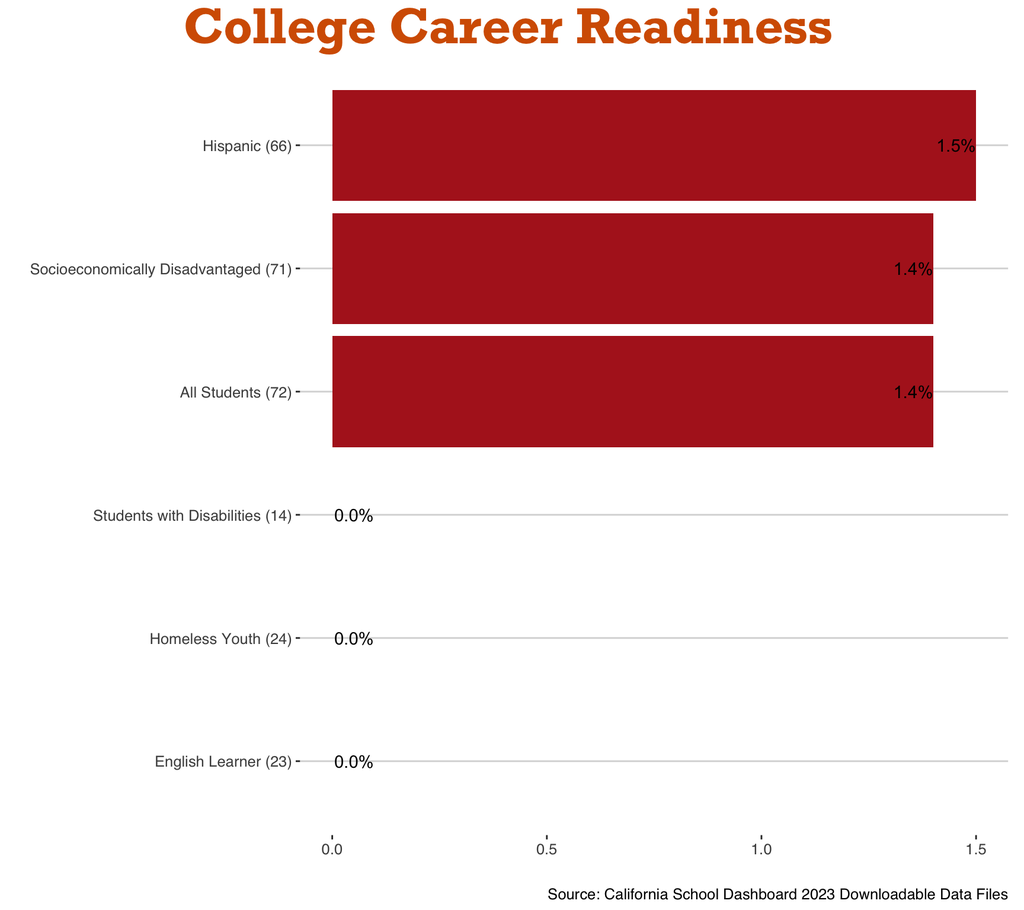

## Historical Graphs for Eligible Groups

**Click here to display graphs**

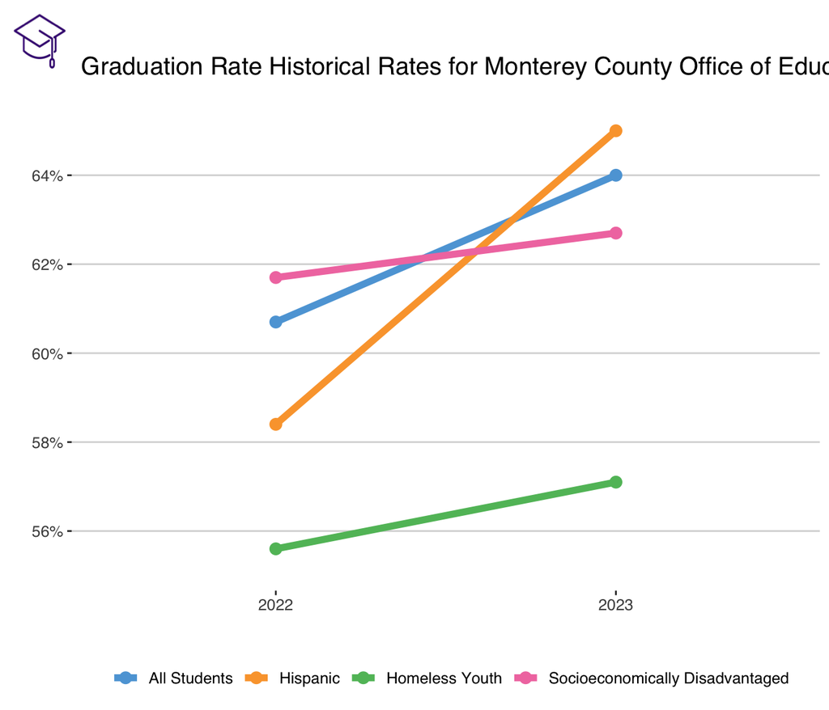

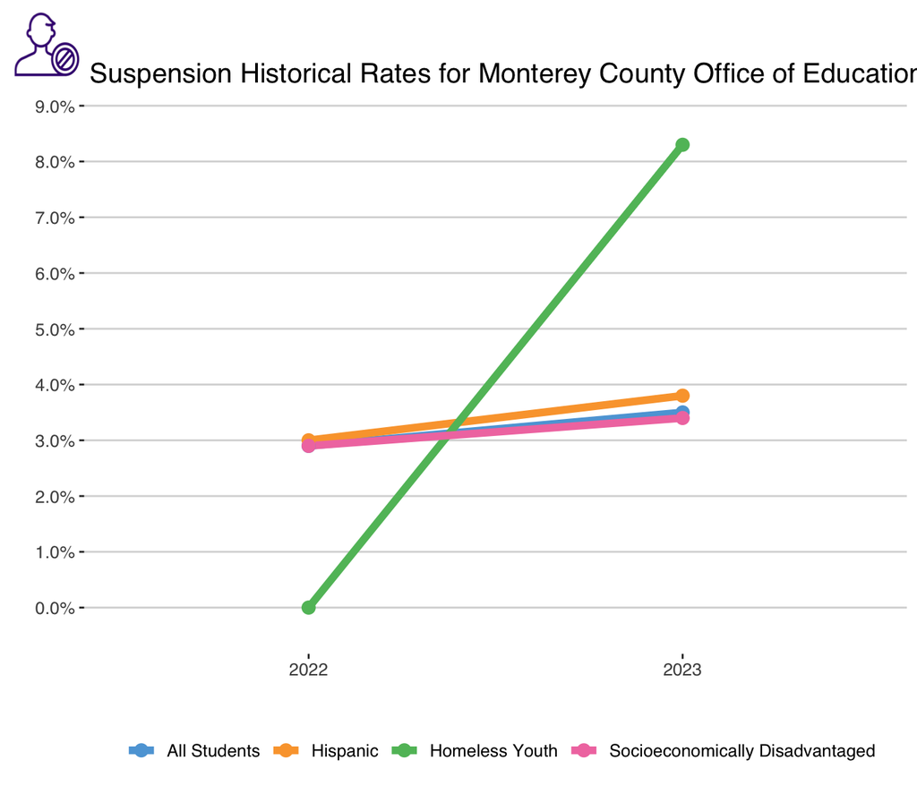